# ATAC-seq Workshop: Part 1

David Oliver

November 10, 2017

# 1. Pre-Alignment Processing

## A. Downloading Publicly Available Data

We will be working with data from “Chromatin Accessibility Landscape of Cutaneous T Cell Lymphoma and Dynamic Response to HDAC Inhibitors” [Published in Cell](http://dx.doi.org/10.1016/j.ccell.2017.05.008) earlier this year.

Specifically we are going to be using data from CTCL patients treated with HDAC inhibitor Romidepsin (Istodax). We are interested in how Romidepsin remodels the chromatin during treatment.

Once you’ve managed to make it past Cell’s pay-wall, you can simply type `Ctrl+f` and `GEO` to find the GEO ID associated with the data in the paper. This paper’s data is stored under GEO accession GSE85853. There are 126 samples associated with this GEO accession. At the bottom of the page you will find the associated SRA project ID SRP082417.

If you want to download all the sequencing data associated with this SRA project ID we can do that in R using the following commands. We won’t actually run this here because you will download the entire SRA database file which is `35.4 GB` and the VM doesn’t have that kind of storage available.

```r
####################################
# R command NOT RUN
####################################

library(SRAdb)                               # load the SRAdb package
srafile = getSRAdbFile()                     # download the SRA database file
con = dbConnect(RSQLite::SQLite(), srafile)  # establish connection to the database (sqlite)
listSRAfile('SRP082417', con)                # show all samples associated witht he project
getSRAfile('SRP082417', con, fileType='sra') # download all associated fastq files
```

If we only want a couple samples from a project we can get those using the sample specific **SRR** number. For this workshop we will be looking at a CTCL patient 1461 who was treated with Romidepsin specifically looking at day 0 `Sample: BulkCTCL_Patient1461_Romi_Day0` and day 28 `Sample: BulkCTCL_Patient1461_Romi_Day28`. To get the associated SRR numbers for these samples we follow the `GSM` link next to the sample and then the `SRX` link at the bottom of that page and finally we arrive at a page where our SRR number exists `SRR4044837` and `SRR4044835`.

Now that we have our SRR IDs in hand we can use the [SRA toolkit](https://github.com/ncbi/sra-tools/wiki/Downloads) to get the FASTQ files associated with the SRR ID. The `fastq-dump` command downloads the `.sra` file to your user directory under `ncbi/public/sra` and converts it to fastq.

Once again we won’t run this because these files are quite large and we don’t have the power to handle aligning them. Also note that the SRA toolkit is a command line toolkit **NOT** an R package

```bash
####################################
# BASH command NOT RUN
####################################

mkdir -p ~/myProject/myFastQs       # make a new project directory and fastq dir
cd ~/myProject/myFastQs             # move to a dir to store fastq files
fastq-dump --split-files SRR4044835 # dump the SRR4044835_1.fastq and SRR4044835_2.fastq files
fastq-dump --split-files SRR4044837 # dump the SRR4044837_1.fastq and SRR4044837_2.fastq files
```

## B. Before Aligning

The following code chunks will be **BASH** commands. These operations all have some R corollary but using R for these steps is highly inefficient and not recommended.

### i. Setting Up the Genome Index

UCSC maintains most of the available genomes. You can download the raw FASTA genome files from [UCSC’s website](http://hgdownload.cse.ucsc.edu/downloads.html) by selecting your organism of interest (we’re using human data here) and selecting [Full data set](http://hgdownload.cse.ucsc.edu/goldenPath/hg38/bigZips/).

Alternately if you know your genome’s location you can use `wget` or `curl` to download the file directly.

```bash
####################################
# BASH command NOT RUN
####################################

mkdir -p ~/myProject/hg38/Genome                                        # make a new genome dir
cd ~/myProject/hg38/Genome                                              # move to the a genome dir
wget http://hgdownload.cse.ucsc.edu/goldenPath/hg38/bigZips/hg38.fa.gz  # download the genome
gunzip hg38.fa.gz                                                       # unzip the genome fasta file
```

We will use [bowtie2](http://bowtie-bio.sourceforge.net/bowtie2/index.shtml) for this example because it’s what most people are using for ATAC-seq data (that doesn’t mean it’s the best!). Feel free to use whatever aligner you enjoy most (I like STAR personally).

```bash
####################################
# BASH command NOT RUN
####################################

mkdir -p ~/myProject/hg38/Genome/bt2                           # move to a directory for your bowtie2 index
bowtie2-build ~/Genomics/genomes_2/hg38/Genome/hg38.fa.gz hg38 # build the bowtie2 index with default parameters
```

### ii. Cleaning Up the Sequences

Now that you have your theoretical genome built and ready to go we can start pre-processing the fastq files. I use [Trim Galore](https://www.bioinformatics.babraham.ac.uk/projects/trim_galore/) which is a wrapper function for [Cutadapt](https://cutadapt.readthedocs.io/en/stable/) and [FastQC](https://www.bioinformatics.babraham.ac.uk/projects/fastqc/).

```bash
####################################
# BASH command NOT RUN
####################################

mkdir ~/myProject/processed                # make a directory for our processed files
cd ~/myProject/processed                   # move into the processed directory
trim_galore --paired \                     # run trim galor in paired end mode
--fastqc \                                 # run fastqc as well
--output_dir ./ \                          # output prefix
~/myProject/myFastQs/SRR4044835_1.fastq \  # read 1
~/myProject/myFastQs/SRR4044835_2.fastq    # read 2

trim_galore --paired --fastqc --output_dir ./ ~/myProject/myFastQs/SRR4044837_1.fastq ~/myProject/myFastQs/SRR4044837_2.fastq
```

### iii. Checking FastQC Output for Major Issues

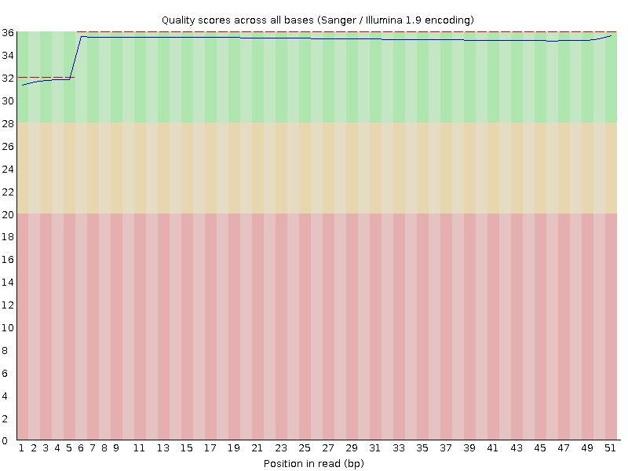

FastQC Per Base Quality Scores (Read 1)

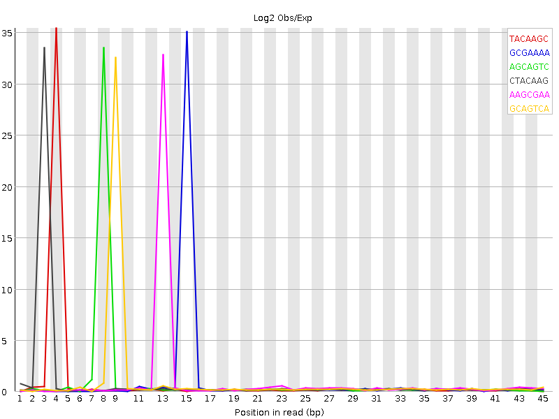

The Quality score looks perfect. Looks like there is an issue with possible adapter contamination? It’s probably safe to move forward with the alignment but we should probably set the aligner to local for best results.

# 2. Aligning to the Genome

Based on the output of FastQC we will set bowtie2 to align using the local alignment option just in case we have additional adapters.

```bash
####################################
# BASH command NOT RUN
####################################

mkdir ~/myProject/aligned
cd ~/myProject/aligned
bowtie2 --local \                                 # Run bowtie2 in local mode
-p 12 \                                           # number of threads to use for alignment
-x ~/myProject/hg38/Genome/bt2/hg38 \             # path to the index plus prefix
-1 ~/myProject/processed/SRR4044837_1_val_1.fq \  # Read 1
-2 ~/myProject/processed/SRR4044837_2_val_2.fq \  # Read 2
-S SRR4044837.sam \                               # name of the output in SAM format
2> SRR4044837.bowtie2.txt                         # send stderr to a txt file for later processing

bowtie2 --local -p 12 -x ~/myProject/hg38/Genome/bt2 -1 ~/myProject/processed/SRR4044835_1_val_1.fq -2 ~/myProject/processed/SRR4044835_2_val_2.fq -S SRR4044835.sam 2> SRR4044835.bowtie2.txt
```

Check the summary report for the alignments.

```bash
echo "SRR4044835 alignment summary"
cat R/SRR4044835.bowtie2.txt
```

```
## SRR4044835 alignment summary
## 20489434 reads; of these:
##   20489434 (100.00%) were paired; of these:
##     987527 (4.82%) aligned concordantly 0 times
##     12598703 (61.49%) aligned concordantly exactly 1 time
##     6903204 (33.69%) aligned concordantly >1 times
##     ----
##     987527 pairs aligned concordantly 0 times; of these:
##       334182 (33.84%) aligned discordantly 1 time
##     ----
##     653345 pairs aligned 0 times concordantly or discordantly; of these:
##       1306690 mates make up the pairs; of these:
##         211745 (16.20%) aligned 0 times
##         353706 (27.07%) aligned exactly 1 time
##         741239 (56.73%) aligned >1 times
## 99.48% overall alignment rate
```

```bash
echo "SRR4044837 alignment summary"
cat R/SRR4044837.bowtie2.txt
```

```
## SRR4044837 alignment summary
## 18200175 reads; of these:
##   18200175 (100.00%) were paired; of these:
##     497844 (2.74%) aligned concordantly 0 times
##     11291185 (62.04%) aligned concordantly exactly 1 time
##     6411146 (35.23%) aligned concordantly >1 times
##     ----
##     497844 pairs aligned concordantly 0 times; of these:
##       139262 (27.97%) aligned discordantly 1 time
##     ----
##     358582 pairs aligned 0 times concordantly or discordantly; of these:
##       717164 mates make up the pairs; of these:
##         162541 (22.66%) aligned 0 times
##         174764 (24.37%) aligned exactly 1 time
##         379859 (52.97%) aligned >1 times
## 99.55% overall alignment rate
```

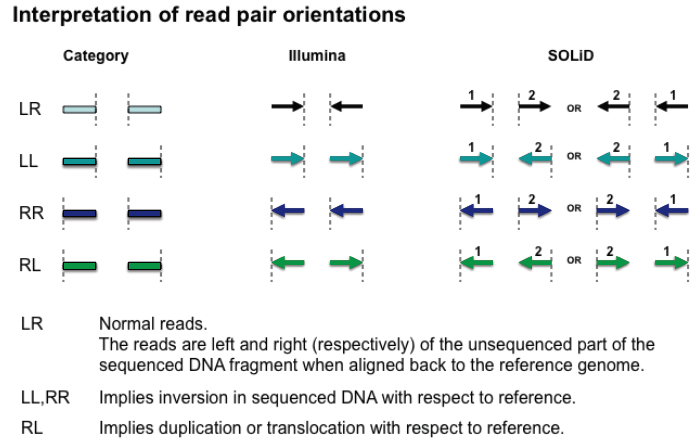

*Borrowed from IGV User Guide*

The first section of the output tells us about the concordant alignment rate. `61.49% + 33.69% = 95.18%` of our reads were paired and aligned at least once concordantly. What does concordance mean when talking about paired end alignment?

The next section of the report deals with the bowtie’s first attempt to deal with the `4.82%` of reads that failed to align at least once concordantly. Bowtie2 finds discordant alignments for `33.84%` of these reads.

The last section deals with the remaining `66.16% of the 4.82%` of reads that didn’t align concordantly and Bowtie2 couldn’t find a good discordant alignment for. By treating these reads as unpaired alignments, Bowtie finds at least 1 alignment for `83.80%` of these.

The overall alignment rate then is `99.48%`.

# 3. Post-Alignment Read Processing

Once the alignment is done, and if the alignment looks good, the aligned reads need to be cleaned up before moving forward. As a last step, for the purposes of this workshop the reads will be subset to only those reads aligning to `chr19` so that we can start doing things in real time.

## A. Filtering and Sorting Alignements

`Samtools` provides a set of tools for manipulating `SAM` and `BAM` files including filtering, sorting, indexing, as well as many, many other tools.

```bash
####################################
# BASH command NOT RUN
####################################

mkdir ~/myProject/post
samtools view -ubh \                       # view the SAM file as uncompressed (u) BAM (b) including headers (h)
-q 1 \                                     # only include reads with a qual score >=1 (unaligned reads get 0)
-F 2828 \                                  # discard (F) unmapped, non-primary, qc failed, and supp alignments
-@ 10 \                                    # use 10 threads (@)
SRR4044835.sam | \                         # From input SAM and pipe the output onwards (|)
samtools sort -@ 10 \                          # Sort the alignments using 10 threads
-o ~/myProject/post/SRR4044835_filtered.bam \  # write the output BAM
-                                              # Get input from STDIN (|)

samtools view -ubh -q 1 -F 2828 -@ 10 SRR4044837.sam | samtools sort -@ 10 -o ~/myProject/post/SRR4044837_filtered.bam -
```

For all the filtering options available, check [SAM Flags Explained.](https://broadinstitute.github.io/picard/explain-flags.html).

Also note that we’ve simply removed multi-mapping reads here causing the loss of ~6 million reads. There are approaches for rescuing these multi-mappers but they are not often used and no meta-analysis of whether these approaches actually improve analysis has been performed to date. Check out [MMR](https://academic.oup.com/bioinformatics/article/32/5/770/1743383) for a quick introduction to the subject.

## B. Removing PCR Duplicates.

In order to remove PCR duplicates they must be marked as duplicates using [Picard’s MarkDuplicates](http://broadinstitute.github.io/picard/command-line-overview.html#MarkDuplicates) function. This step is performed after initial filtering to improve performance.

```bash
####################################
# BASH command NOT RUN
####################################

java -Xmx12g -jar /opt/picard.jar MarkDuplicates \    # start Picard MarkDuplicates with 12Gb of RAM
REMOVE_DUPLICATES=TRUE \                              # Remove duplicates if found (don't just mark them)
I=~/myProject/post/SRR4044835_filtered.bam \          # Input BAM
O=~/myProject/post/SRR4044835_filtered_noDup.bam \    # Output BAM
METRICS_FILE=~/myProject/post/SRR4044835_dedup.txt \  # Generate a metrics file
VALIDATION_STRINGENCY=LENIENT \                       # Try not to complain too much
ASSUME_SORTED=TRUE                                    # The input BAM is sorted

java -Xmx12g -jar /opt/picard.jar MarkDuplicates REMOVE_DUPLICATES=TRUE I=~/myProject/post/SRR4044837_filtered.bam O=~/myProject/post/SRR4044837_filtered_noDup.bam METRICS_FILE=~/myProject/post/SRR4044837_dedup.txt VALIDATION_STRINGENCY=LENIENT ASSUME_SORTED=TRUE
```

`MarkDuplicates` metric file provides some summary statistics.

```r
####################################
# R command
####################################
library(knitr)
SRR4044835_dedup <- read.table(file = "R/SRR4044835_dedup.txt",  # read in our dedup metrics
                               nrows = 1,                        # Only grab the first row (after headers)
                               header = T)                       # use the first row as headers
SRR4044837_dedup <- read.table(file = "R/SRR4044837_dedup.txt",
                               nrows = 1,
                               header = T)
dedup_summary <- rbind(SRR4044835_dedup[,c(3,7,9)],
                       SRR4044837_dedup[,c(3,7,9)])              # combine our two library metrics
rownames(dedup_summary) <- c("SRR4044835", "SRR4044837")         # add meaningful names
kable(dedup_summary)                                             # make a pretty html table
```

|  | READ_PAIRS_EXAMINED | READ_PAIR_DUPLICATES | PERCENT_DUPLICATION |
| --- | --- | --- | --- |
| SRR4044835 | 20299621 | 1414774 | 0.069695 |
| SRR4044837 | 18057687 | 813519 | 0.045051 |

About `4.5% - 7%` of these libraries were PCR duplicates.

Picard also provides a nice metric for whether or not additional sequencing would improve coverage based on how much duplication was observed.

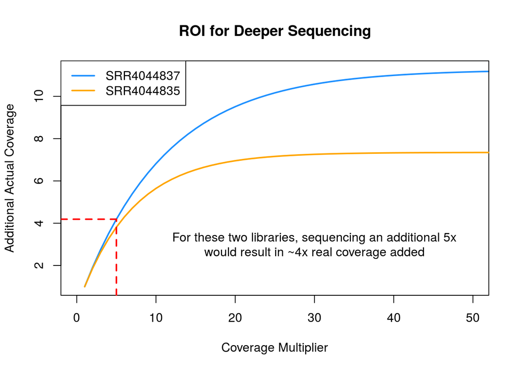

```r
####################################
# R command
####################################
SRR4044835 <- read.table(file = "R/SRR4044835_dedup.txt",  # read in our dedup metrics
                         skip = 10,                        # skip to the data we want
                         header = T)                       # use the first row as headers
SRR4044837 <- read.table(file = "R/SRR4044837_dedup.txt",
                         skip = 10,
                         header = T)

plot(x    = SRR4044837$BIN,                # plot BIN as X values
     y    = SRR4044837$VALUE,              # plot VALUE as Y values
     xlim = c(0,50),                       # set the range of Xs to 0-50
     type = "l",                           # plot the data as a line
     lwd  = 2,                             # set the line width to 2
     col  = "dodgerblue",                  # set the color of the line
     xlab = "Coverage Multiplier",         # x label
     ylab = "Additional Actual Coverage",  # y label
     main = "ROI for Deeper Sequencing")   # main title
lines(x   = SRR4044835$BIN,                # add a line to the existing plot
      y   = SRR4044835$VALUE,
      lwd = 2,
      col = "orange")
segments(x0  = 5, x1  = 5,                        # add a line segment to the existing plot
         y0  = 0, y1  = SRR4044837$VALUE[5],
         col = "red", lwd = 2,
         lty = 2)                                 # set the line type to 2 (dashes)
segments(x0 = -2, x1 = 5,
         y0 = SRR4044837$VALUE[5],
         y1 = SRR4044837$VALUE[5],
         col = "red", lty = 2, lwd = 2)
legend("topleft",                                 # add a legend to the top left of the plot
       lwd = 2,
       col = c("dodgerblue", "orange"),
       legend = (c("SRR4044837", "SRR4044835")))
text(x = 30,                                      # add additional descriptive text
     y = 3,
     labels = "For these two libraries, sequencing an additional 5x\nwould result in ~4x real coverage added")
```

## C. Removing chrM Reads

Samtools’ `idxstats` function returns the number of reads aligning to each chromosome. The percentage of reads aligning to chrM can be a useful metric for the quality of the ATAC-seq experiment. Although reads aligning to chrM can often be greater than 50%, a well done ATAC-seq experiment should have less than 5% of reads aligning to chrM.

First generate the index using Samtools’ `index` function. The `bai` index is also used by almost every program for downstream BAM manipulation allowing them to find reads quickly and efficiently.

```bash
####################################
# BASH command NOT RUN
####################################

cd ~/myProject/post
samtools index SRR4044835_filtered_noDup.bam  # generate an index for the bam file.
samtools index SRR4044837_filtered_noDup.bam

samtools idxstats SRR4044835_filtered_noDup.bam > SRR4044835_idxStats.txt  # write the index stats to file
samtools idxstats SRR4044837_filtered_noDup.bam > SRR4044837_idxStats.txt
```

Visualize the index statistics.

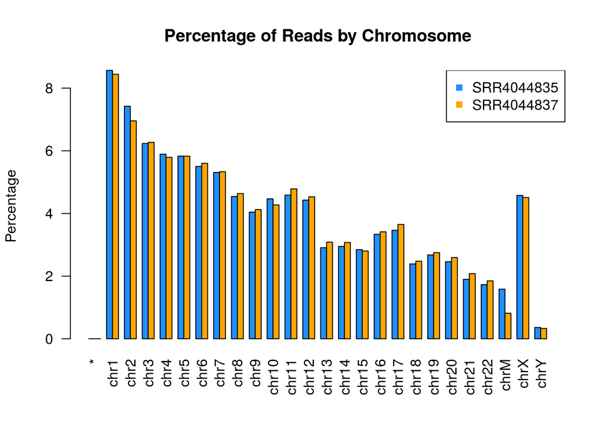

```r
####################################
# R command
####################################
library(gtools); library(magrittr); library(plyr)
SRR4044835_idxStats <-
    read.delim("R/SRR4044835_idxStats.txt",
               stringsAsFactors = F,         # don't convert strings to factors
               header = F) %>%               # the `%>%` operator is equivalent to `|`
    .[mixedorder(.$V1),] %>%                 # mixed sort so chr1 is followed by chr2 (not chr10)
    mutate(., Percent = V3/sum(V3)*100)      # create a new column with percentage of reads
SRR4044837_idxStats <-
    read.delim("R/SRR4044837_idxStats.txt", stringsAsFactors = F, header = F) %>%
    .[mixedorder(.$V1),] %>%
    mutate(., Percent = V3/sum(V3)*100)

rbind(SRR4044835_idxStats$Percent,                          # combine both datasets
      SRR4044837_idxStats$Percent) %>%
    barplot(., beside = T,                                  # barplot the two datasets side by side
            names.arg = SRR4044835_idxStats$V1,             # use the chromosome names
            las = 2,                                        # plot the xlab vertically
            col = c("dodgerblue", "orange"),                # colors
            main = "Percentage of Reads by Chromosome",     # main title
            ylab = "Percentage")                            # y label
legend("topright", legend = c("SRR4044835", "SRR4044837"),  # add a legend
       col = c("dodgerblue", "orange"), pch = 15)
```

Now remove the chrM reads. This step uses Samtools instead of a simple grep command because it scales to large datasets.

```bash
####################################
# BASH command NOT RUN
####################################

cat SRR4044835_idxStats.txt | \    # Read the indxstats to STDIN
cut -f 1 | \                       # Get the chromosome names
grep -v chrM | \                   # Remove chrM from the list of chromosomes
xargs samtools view -hb \          # pass the chromosome names to samtools
SRR4044835_filtered_noDup.bam > \  # the file to keep chromosomes
SRR4044835_filtered_noDup_noM.bam  # the output chrM removed

cat SRR4044837_idxStats.txt | cut -f 1 | grep -v chrM | xargs samtools view -hb SRR4044837_filtered_noDup.bam > SRR4044837_filtered_noDup_noM.bam
```

## D. Removeing Blacklisted Regions

There are a set of regions in the genome that are considered “black listed” due to artifacts in both genome assembly and highly repetitive regions with hyper mappability.

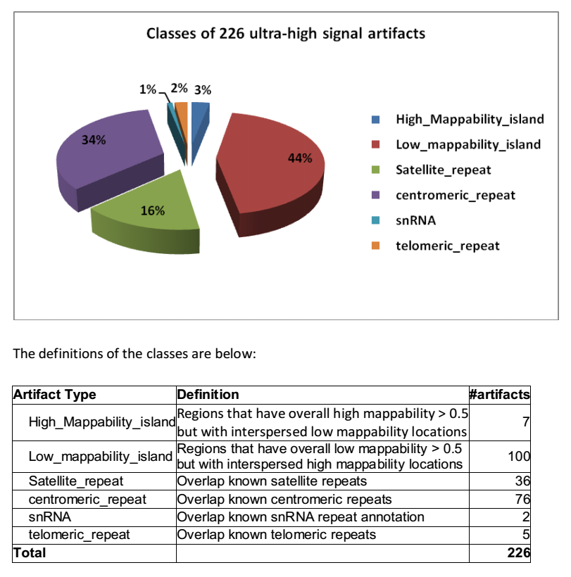

See [this readme](https://personal.broadinstitute.org/anshul/projects/encode/rawdata/blacklists/hg19-blacklist-README.pdf) for a thorough description about how blacklisted regions are annotated.

The blacklisted regions for hg38 can be downloaded from [here](http://mitra.stanford.edu/kundaje/akundaje/release/blacklists/hg38-human/hg38.blacklist.bed.gz). Notice that the blacklist for hg38 only contains 38 regions (226 in hg19). This is mostly due to improvements in the hg38 build.

`Bedtools` provides a set of tools for manipulating `BED` files including subsetting, indexing, and statistical calculations.

```bash
####################################
# BASH command NOT RUN
####################################

cd ~/myProject
wget http://mitra.stanford.edu/kundaje/akundaje/release/blacklists/hg38-human/hg38.blacklist.bed.gz
gunzip hg38.blacklist.bed.gz

cd ~/myProject/post
bedtools subtract \                        # bedtools subtract function
-A \                                       # remove all reads from a overlapping file b
-abam SRR4044835_filtered_noDup_noM.bam \  # file a is a bam file
-b ~/myProject/hg38.blacklist.bed > \      # file b is out blacklist regions
SRR4044835_filtered_noDup_noM_noblack.bam  # write the output

bedtools subtract -A -abam SRR4044837_filtered_noDup_noM.bam -b ~/myProject/hg38.blacklist.bed > SRR4044837_filtered_noDup_noM_noblack.bam
```

## E. Adjusting Read Location for Tn5 Cutting

The final step in post-processing is to adjust the read positions by a small offset in order to align the read to it’s true location. Because the Tn5 transposase cuts in a staggered fashion, the resulting library of reads have `+` strand shifted downstream 4bp while the `-` strand is shifted upstream 5bp. Reversing this improves the accuracy of the open chromatin prediction.

```bash
####################################
# BASH command NOT RUN
####################################

####################################
# BEGIN Tn5Adjust.sh script

#!/bin/bash -l
# Adjusts BAM read-ends by Tn5 offsets (+4 for forward, and -5 for reverse)
tn5_adjust='        # tn5_adjust is an awk function
BEGIN {OFS = FS} {  # use the set the original files field separator
  if ($2 == 0) {    # if the read is on the positive strand
    $4 = $4 + 4     # shift the alignment upstream 4bp
  } else {
    $4 = $4 - 5     # else shift it downstream 5bp
  }
  if ($4 < 1) {     # if we hit the beginning of the chromosome do nothing
      $4 = 1
  }
  print $0          # return all rows
}
'
SAMPLE=$1                                    # The input BAM
THREADS=$2                                   # Number of threads for samtools
samtools view -H $1 > ${SAMPLE}.tmp          # Store the original header
samtools view $1 | \                         # Read in the BAM as SAM
awk -F $'\t' "$tn5_adjust" >> ${SAMPLE}.tmp  # Run the awk function appending to the header file
samtools view -hb -@ $THREADS \              # Revert SAM back to BAM
-o ${SAMPLE%.bam}_tn5Adj.bam ${SAMPLE}.tmp   # The output file
rm ${SAMPLE}.tmp                             # remove the tmp file
exit 0

# END Tn5Adjust.sh script
#############################

tn5Adjust.sh SRR4044835_filtered_noDup_noM_noblack.bam 12
tn5Adjust.sh SRR4044837_filtered_noDup_noM_noblack.bam 12
```

## F. Final Sorting and Regenerating Index

Since the reads have been shuffled and dropped the final BAM needs to be re-sorted and re-indexed.

```bash
####################################
# BASH command NOT RUN
####################################

samtools sort -@ 10 -o SRR4044835_filtered_noDup_noM_noblack_tn5Adj_sorted.bam SRR4044835_filtered_noDup_noM_noblack_tn5Adj.bam
samtools sort -@ 10 -o SRR4044837_filtered_noDup_noM_noblack_tn5Adj_sorted.bam SRR4044837_filtered_noDup_noM_noblack_tn5Adj.bam

samtools index SRR4044835_filtered_noDup_noM_noblack_tn5Adj_sorted.bam
samtools index SRR4044837_filtered_noDup_noM_noblack_tn5Adj_sorted.bam
```

I’ve presented the above section in a procedural format but in reality this is all written into a single script which can be distributed to a node on the server cluster and runs rather painlessly.

# 4. Peak Calling

Now that the data is cleaned and processed, it’s time to call peaks. [MACS2](https://github.com/taoliu/MACS) is the gold standard for ChIP and ATAC-seq peak calling. This doesn’t mean it’s the best, but it is the standard and used by ENCODE.

## A. Calling Peaks with `MACS2`

`MACS2` is the recommended peak caller for ATAC-seq according to the [Encode Consortium](https://www.encodeproject.org/pipelines/ENCPL583EZV/). It’s fairly simple to use, light weight, and produces convenient outputs (including excel).

```bash
####################################
# BASH command NOT RUN
####################################

mkdir ~/myProject/peaks/
for i in $(ls *_sorted.bam); do       # for each pseudoreplicate
  macs2 callpeak --broad \            # MACS2 callpeaks function aggregating nearby peaks
--format BAMPE \                      # let MACS2 use paired end information
--nomodel --shift -37 --extsize 73 \  # Don't use default shift, instead use -37 and 73
--bdg \                               # Create a bedgraph output
--gsize 2.5e9 \                       # The mappable genome size
-t $i \                               # Treatment file
-n ~/myProject/peaks/${i%.bam}        # Output prefix
done
```

`MACS2` outputs bedgraph (`.bdg`), broadPeak (`.broadPeak`), gappedPeak (`gappedPeak`), and an excel (`.xls`) file all containing information about the peaks called.

## B. Assessing Reproducibility

In a case like this one where there are no biological replicates (this is often the case with ATAC-seq), reproducibility is measured at a technical, rather than biological, level.

### i. Generating Pseudoreplicates

In order to assess our peak reproducibility, the single samples must be split into pseudo-replicates. The following bash script performs this function.

```bash
####################################
# BASH command NOT RUN
####################################

####################################
# BEGIN splitBAM.sh

#!/bin/bash -l
# subsample BAM file for IDR on pseudoreplicates

SAMPLE=$1
THREADS=$2

NLINES=$( samtools view ${SAMPLE} | wc -l )
NLINES=$(( (NLINES + 1) / 2 ))

OUTNAME=${SAMPLE%.bam}_sample_

samtools view -H ${SAMPLE} > ${OUTNAME}00.sam
cp ${OUTNAME}00.sam ${OUTNAME}01.sam

samtools view ${SAMPLE} | shuf | split -d -l ${NLINES} - ${OUTNAME}
cat ${OUTNAME}00 >> ${OUTNAME}00.sam
cat ${OUTNAME}01 >> ${OUTNAME}01.sam

samtools view -hb -@ ${THREADS} ${OUTNAME}00.sam -o ${OUTNAME}00.bam
samtools view -hb -@ ${THREADS} ${OUTNAME}01.sam -o ${OUTNAME}01.bam

rm ${OUTNAME}00.sam ${OUTNAME}01.sam ${OUTNAME}00 ${OUTNAME}01
exit 0

# END splitBAM.sh
####################################

splitBAM.sh SRR4044835_filtered_noDup_noM_noblack_tn5Adj_sorted.bam 12
splitBAM.sh SRR4044837_filtered_noDup_noM_noblack_tn5Adj_sorted.bam 12

for i in $(ls *_sample_*);          # for each pseudoreplicate
  do samtools sort -@ 10 -o $i $i;  # sort in place
done
```

### ii. Calling Differential Peaks Between Pseudoreplicates

Peaks are called as before.

```bash
####################################
# BASH command NOT RUN
####################################

for i in $(ls *_sample_*); do         # for each pseudoreplicate
  macs2 callpeak --broad \            # MACS2 callpeaks function aggregating nearby peaks
--format BAMPE \                      # let MACS2 use paired end information
--nomodel --shift -37 --extsize 73 \  # Don't use default shift, instead use -37 and 73
--bdg \                               # Create bedgraph output
--gsize 2.5e9 \                       # The mappable genome size
-t $i \                               # Treatment file
-n ~/myProject/peaks/${i%.bam}        # Output prefix
done
```

`MACS2` produces bedGraphs which can be used in a separate call to the `bdgdiff` function of `MACS2`. `MACS2 bdgdiff` calculates differential binding between experiments.

In this case it will calculated differentially open regions between pseudo-replicates. Peaks called as differential between pseudo-replicates can be considered low stability and can be removed before further processing.

```bash
####################################
# BASH command NOT RUN
####################################

cd ~/myProject/peaks/
macs2 bdgdiff \
-l 147 \
-g 73 \
--t1 SRR4044835*00_treat_pileup.bdg \
--t2 SRR4044835*01_treat_pileup.bdg \
--c1 SRR4044835*00_control_lambda.bdg \
--c2 SRR4044835*01_control_lambda.bdg \
--o-prefix SRR4044835_PR

macs2 bdgdiff -l 147 -g 73 --t1 SRR4044837*00_treat_pileup.bdg --t2 SRR4044837*01_treat_pileup.bdg --c1 SRR4044837*00_control_lambda.bdg --c2 SRR4044837*01_control_lambda.bdg --o-prefix SRR4044837_PR

wc -l *.bed > ../R/bdgdiff.txt        # count the number of peaks in bdgdiff output
wc -l *.broadPeak > ../R/numPeaks.txt # count number of peaks in original macs2 calls
```

```r
library(edgeR)
diff <-
    read.table("R/bdgdiff.txt", stringsAsFactors = F) %>%  # read in diff peaks
    .[-7, ] %>%                                            # trim off empty columns
    `colnames<-` (., c("Peaks", "Samples"))                # rename columns
diff$Samples <-
    strsplit2(diff$Samples, "_")[,c(1,4)] %>%              # Fix sample names
    apply(., 1, paste, collapse = "_")                     # more fixing

num <-
    read.table("R/numPeaks.txt", stringsAsFactors = F) %>% # read in original peak numbers
    .[-7, ] %>%                                            # drop empty column
    `colnames<-` (., c("Raw_Peaks", "Samples"))            # rename columns
num$Samples <-
    strsplit2(num$Samples, "_")[,c(1,9)] %>%               # fix sample names
    apply(., 1, paste, collapse = "_")

cbind(num, diff) %>%                 # combine datasets
    `rownames<-` (., .$Samples) %>%  # make rownames
    .[,-2] %>%                       # drop columns that had rownames
    kable()
```

|  | Raw_Peaks | Peaks | Samples |
| --- | --- | --- | --- |
| SRR4044835_ | 27968 | 10030 | SRR4044835_common.bed |
| SRR4044835_00 | 18030 | 285 | SRR4044835_cond1.bed |
| SRR4044835_01 | 18069 | 301 | SRR4044835_cond2.bed |
| SRR4044837_ | 12990 | 1353 | SRR4044837_common.bed |
| SRR4044837_00 | 6222 | 141 | SRR4044837_cond1.bed |
| SRR4044837_01 | 6176 | 143 | SRR4044837_cond2.bed |

Of the original ~28k peaks in the `SRR4044835` sample, ~10k were stable after subsampling. Only ~1.3k peaks were stable in the `SRR4044837` sample out of the original ~13k. This indicates that the depth of sequencing for `SRR4044837` is too low and re-sequencing this sample would significantly improve the analysis.

## C. Counting Reads in Peaks and Calculating FRiP

reproducibility between pseudo-replicates is used to determine if there is strong evidence for a particular peak call. This is an ad-hoc method for incorporating replicate information into ChIP and ATAC-seq peak calling.

### i. Generate Feature Table

First, generate a GTF file from the full depth `MACS2` peaks. This requires 2 tools from the `UCSC toolkit`: `bedToGenePred` and `genePredToGtf`. These tools can be found [here](https://github.com/ENCODE-DCC/kentUtils) and are named after the developer (Jim Kent) for some unknown reason.

```bash
####################################
# BASH command NOT RUN
####################################

mkdir ~/myProject/annotations
cat $(ls *sorted_peaks.broadPeak) | \            # concatentate all the peaks (necessary whne more than 2 samples)
cut -f 1,2,3,4 | \                               # cut everything beyond the first 4 columns (broadPeak -> bed)
sort -k 1,1 -k 2,2n | \                          # sort by chromosome and then position
bedtools merge -d 150 -c 4 -o first -i - | \     # merge peaks within 150bp and select first peak name
bedToGenePred stdin stdout | \                   # convert from bed to predicted "genes"
genePredToGtf file stdin stdout | \              # creat a GTF file from the "predicted genes"
tr '\000' '.' | \                                # clean up a strange conversion issue
awk '{if ($3 == "exon") print $0;}' > \          # only keep exon's (reduces the size of the gtf)
~/myProject/annotations/AllPeaks_union.gtf       # write it to gtf file
```

### ii. Count Reads in Features

Next, the number of reads overlapping the peaks in the newly generated GTF file can be counted. [featureCounts](http://bioinf.wehi.edu.au/featureCounts/) is a part of the [Subreads](http://subread.sourceforge.net/) software which was designed to streamline the RNA-seq alignment, counting, and differential expression pipeline. This is by far the best available read count package.

```bash
####################################
# BASH command NOT RUN
####################################

cd ~/myProject/annotations/
BAMFILES=`find ~/myProject/post -name "*_sorted.bam" | tr '\n' ' '`  # find bam files for counting

featureCounts -T 6 \     # run featureCounts with 6 threads
-f \                     # summarize at the exon level
-O \                     # count fraction of multi-overlapping reads
-t exon \                # count reads in exons
-g gene_id \             # use gene_id as name field
-a AllPeaks_union.gtf \  # our annotation file
-o Peak_counts.txt \     # write the output
$BAMFILES 2> \           # take input bams and send STDERR on
Peak_counts.log          # write STDERR to log file
```

The ENCODE Consortium scrutinizes experiments in which the FRiP falls below 1%. We can get the FRiP score from the featureCount log file.

```bash
####################################
# BASH command NOT RUN
####################################

find ../post -name "*_sorted.bam" | \   # find the bam files
cut -d'/' -f3 | \                       # remove leading directory names
cut -d'_' -f1,7,8,9 > \                 # just the important bits
../R/bam_names.txt                      # write it to file

grep Successfully Peak_counts.log | \   # find the keyword 'Successfully' in the log file
tr -d '||' | \                          # remove some ugly stuff
cut -d':' -f2 > \                       # return just the FRiP score
../R/FRiP.txt                           # write it to a file
```

Switch over to `R` to print the FRiP score in a pretty table.

```r
bamnames <- read.table("R/bam_names.txt", stringsAsFactors = F)
frip <-
    read.table("R/FRiP.txt") %>%
    cbind(bamnames, .) %>%
    `colnames<-` (., c("BAM", "READS", "FRiP"))

kable(frip[order(frip$BAM),])
```

| BAM | READS | FRiP |
| --- | --- | --- |
| SRR4044835_sorted.bam | 3735597 | (10.1%) |
| SRR4044837_sorted.bam | 1742536 | (5.1%) |

The FRiP score shows that the experiment is within ENCODE’s standards. Additionally, sample SRR4044837 seems to have underperformed compared to SRR4044835.

## D. Differentially Open Chromatin

The final step is to calculate differentially open chromatin between samples with MACS2.

```bash
####################################
# BASH command NOT RUN
####################################

macs2 bdgdiff \
-l 147 \
-g 73 \
--t1 ../peaks/SRR4044835*sorted_treat_pileup.bdg \
--t2 ../peaks/SRR4044837*sorted_treat_pileup.bdg \
--c1 ../peaks/SRR4044835*sorted_control_lambda.bdg \
--c2 ../peaks/SRR4044837*sorted_control_lambda.bdg \
--o-prefix Diff_Open_Chromatin
```

The next portion of this workshop will cover working with these data.

# 5. MultiQC

[MultiQC](http://multiqc.info/) is not specifically for ATAC-seq but it is an amazing tool for QC. `MultiQC` aggregates all QC metrics from 56 different programs.

`MultiQC` is run as the last check for quality of each step of the pipeline. `MultiQC` collects stats for `Cutadapt`, `FastQC`, `bowtie2`, `MACS2`, and `featureCount`. Probably the most useful bioinformatics tool that’s been released in the past 2 years. The final report is in html format.

# 6. NucleoATAC

The [NucleoATAC](http://nucleoatac.readthedocs.io/en/latest/) is a program for calling nucleosome positions and occupancy using ATAC-Seq data. See the [Genome Research](http://genome.cshlp.org/content/25/11/1757) paper for detailed description of the biological interpretation of these data.

The program is broken down into two portions `nucleoatac` and `pyatac` which perform complementary functions. In addition to these two functions the Greenleaf lab has provided an NucleoATACR for working with the output from NucleoATAC in R.

Before running `nucleoatac`, the genome fasta must be indexed using `samtools faidx`. NucleoATAC generates nucleosome occupancy tracks, normalized V-plots, nucleosome dyad calls, and nucleosome free positions.

```bash
####################################
# BASH command NOT RUN
####################################

samtools faidx ~/myProject/hg38/Genome/genome.fa                  # Generate genome index

nucleoatac run --cores 12 \                                       # run nucleoatac with 12 cores
--bed ../peaks/SRR4044835*sorted_peaks.broadPeak \  # input bed file
--bam ../post/SRR4044835*_sorted.bam \  # input bam file
--fasta ~/myProject/hg38/Genome/genome.fa \                       # genome file (same dir as index)
--out SRR4044835                                                  # output prefix

for f in $(ls *.eps);
  do convert -density 100 $f -flatten ${f%.*}.png;                # convert eps to png
done
```

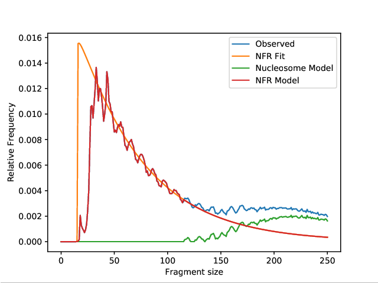

`occ` files contain occupancy information and `nfrpos` files contain nucleosome free positions

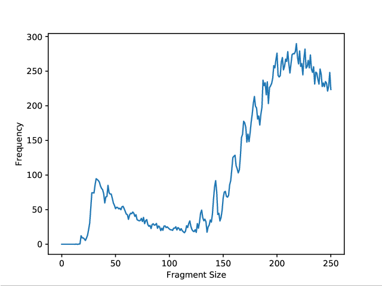

`nucpos` files contain nucleosome dyad calls

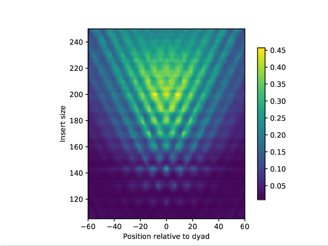

`VMat` files contain V-plot data

NucleoATACR can be used to generate these same figures with additional parameters from the NucleoATAC output files.